# P4 latihan

Kamilah Nurul Azizah

2023-09-21

## White Noise

Pembangkitan data berpola AR, MA, ARMA, dan banyak proses deret waktu lainnya diawali pembangkitan *white noise*. *White noise* merupakan sederet nilai dari peubah bebas stokastik identik. Oleh karena itu, *white noise* memiliki dua karakteristik penting:

1. *White noise* tidak memiliki autokorelasi (**karena saling bebas**)
2. Nilai harapan dan ragam *white noise* sama (**karena berasal dari peubah acak bebas stokastik identik**)

*White noise* dibangkitkan dari suatu peubah acak, umumnya peubah acak normal.

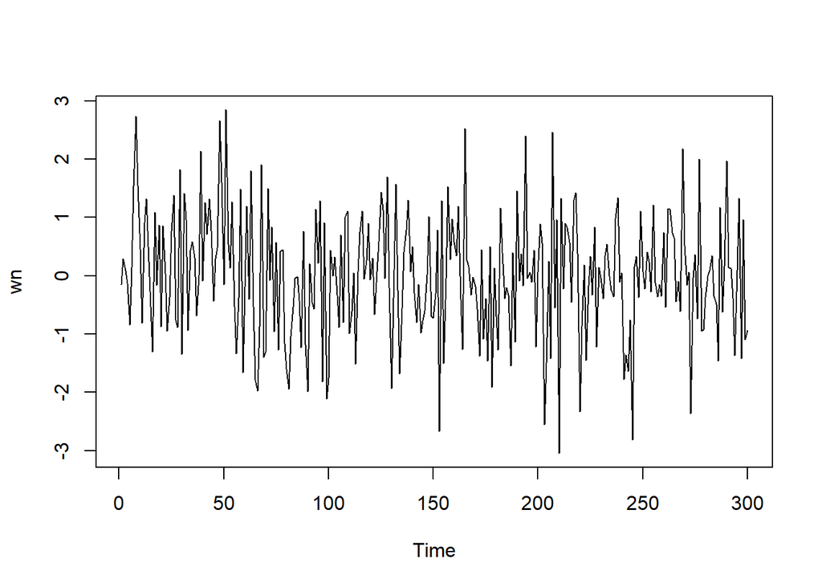

```r
set.seed(073)
wn <- rnorm(300)
ts.plot(wn)
```

Dapat terlihat bahwa *white noise* tidak memiliki autokorelasi dari ACF. Perhatikan bahwa lag ke-0 adalah korelasi observasi ke-t dengan dirinya sendiri. Nilai korelasi tersebut pasti 1. Sebagai alternatif, lag pertama di plot ACF dapat ditetapkan sebagai 1 (alih-alih 0) dengan menambahkan argumen `xlim(1, lag akhir)`. Plot tersebut dapat disandingkan bersamaan dengan membuat matriks $1 \times 2$ dengan `par(mfrow = c(1,2))`.

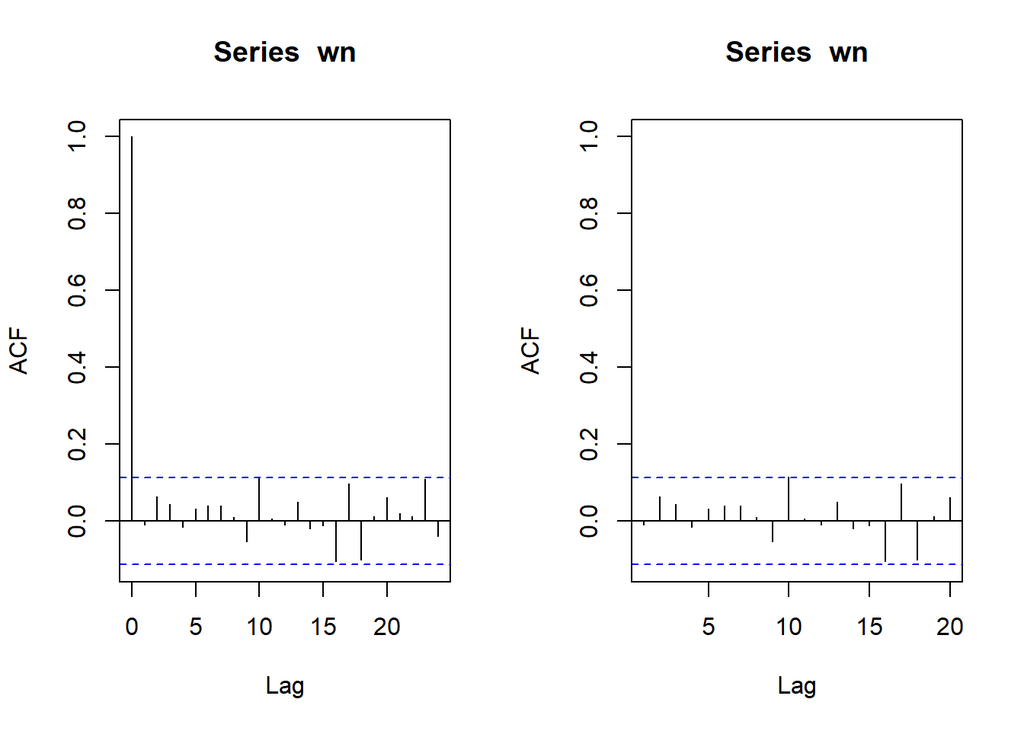

```r
par(mfrow = c(1, 2))
acf(wn)
acf(wn, xlim = c(1, 20))
```

## Proses MA

Proses MA dapat dituliskan sebagai berikut:

$$y_{t} = c + e_t + \theta_{1}e_{t-1} + \theta_{2}e_{t-2} + \dots +
\theta_{q}e_{t-q} = c+{e_t+\sum_{i=1}^p \theta_ie_{t-i}}$$
Terlihat bahwa $e_t$, atau *white noise*, berperan penting dalam pembangkitan proses MA.

## Pembangkitan Proses MA(2)

MA(2) dengan $\theta_1 = 0.4$ dan $\theta_2=0.6$ sebanyak 300 observasi dan $c=0$. Karena diperlukan dua nilai awal untuk $e_{t-1}$ dan $e_{t-2}$, masukkan nilai pertama dan kedua white noise sebagai nilai awal tersebut.

```r
set.seed(073)
ma <- wn[c(1,2)]
```

Nilai-nilai selanjutnya dapat dicari melalui *loop*. Bentuk loop dapat dilihat dari rumus MA(2) yang hendak dibangkitkan:

$$y_t = e_t+0.4e_{t-1}+0.6e_{t-2}$$

```r
for(i in 3:300){
   ma[i] <- wn[i] + 0.4 * wn[i - 1] + 0.6 * wn[i-2]
}
ma
```

```
##   [1] -0.14504691  0.29135800  0.12331246  0.08496588 -0.84149976 -0.27398729
##   [7]  1.08579621  3.43851872  3.56919346  2.72533760  0.30540490  0.85829982
##  [13]  1.19602414  1.57447881  0.47141530 -1.21399136  0.25540415 -0.50793846
##  [19]  1.45617955 -0.62102948  1.02630223 -0.14556241 -0.42166034 -0.73092074
##  [25]  0.04439800  1.46528904  0.25396704 -0.35636573  1.01791381 -1.14584421
##  [31]  1.97569955  0.72727272  0.30647402  0.64908617  0.20087022  0.81060701
##  [37] -0.21195670 -0.07582832  1.73444171  0.78196488  2.51136395  1.16592001
##  [43]  2.36072073  1.73202066  0.66556235  0.58048539  0.33317555  3.02579859
##  [49]  2.95974700  2.09135160  3.75294539  1.59823021  2.05741014  1.64778502
##  [55]  0.05428414 -0.78813732 -1.22972997  0.53568418 -1.29146257  0.04063329
##  [61]  0.11865003 -0.04108546  2.35937206 -0.04889490 -0.91521168 -3.00905097
##  [67] -2.73907861  0.37411931 -1.16391294 -0.71541680  0.13549635 -0.25991885
##  [73]  1.70105138 -0.67344480  0.69551754 -1.61287074  0.25617285 -0.14330040
##  [79] -0.72995774 -1.79078625 -3.27711289 -2.77911656 -2.11619386 -0.88191185
##  [85] -0.35341678 -0.45790314 -1.41227893  0.01844216 -1.61308478 -2.00097369
```

[output cut: 35 more lines]

Selain menggunakan cara di atas, pembangkitan proses MA(2) dapat dilakukan dengan fungsi `arima.sim()` sebagai berikut.

```r
set.seed(073)
ma1 <- arima.sim(list(order=c(0,0,2), ma=c(0.4,0.6)), n=300)
ma1
```

```
## Time Series:
## Start = 1
## End = 300
## Frequency = 1
##   [1]  0.12331246  0.08496588 -0.84149976 -0.27398729  1.08579621  3.43851872
##   [7]  3.56919346  2.72533760  0.30540490  0.85829982  1.19602414  1.57447881
##  [13]  0.47141530 -1.21399136  0.25540415 -0.50793846  1.45617955 -0.62102948
##  [19]  1.02630223 -0.14556241 -0.42166034 -0.73092074  0.04439800  1.46528904
##  [25]  0.25396704 -0.35636573  1.01791381 -1.14584421  1.97569955  0.72727272
##  [31]  0.30647402  0.64908617  0.20087022  0.81060701 -0.21195670 -0.07582832
##  [37]  1.73444171  0.78196488  2.51136395  1.16592001  2.36072073  1.73202066
##  [43]  0.66556235  0.58048539  0.33317555  3.02579859  2.95974700  2.09135160
##  [49]  3.75294539  1.59823021  2.05741014  1.64778502  0.05428414 -0.78813732
##  [55] -1.22972997  0.53568418 -1.29146257  0.04063329  0.11865003 -0.04108546
##  [61]  2.35937206 -0.04889490 -0.91521168 -3.00905097 -2.73907861  0.37411931
```

[output cut: 39 more lines]

### Plot Time Series

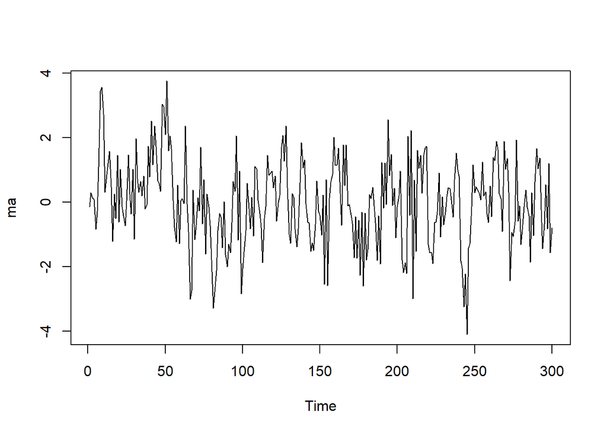

```r
ts.plot(ma)
```

Berdasarkan plot time series, terlihat bahwa data MA(2) yang dibangkitkan stasioner dalam rataan.

### Plot ACF

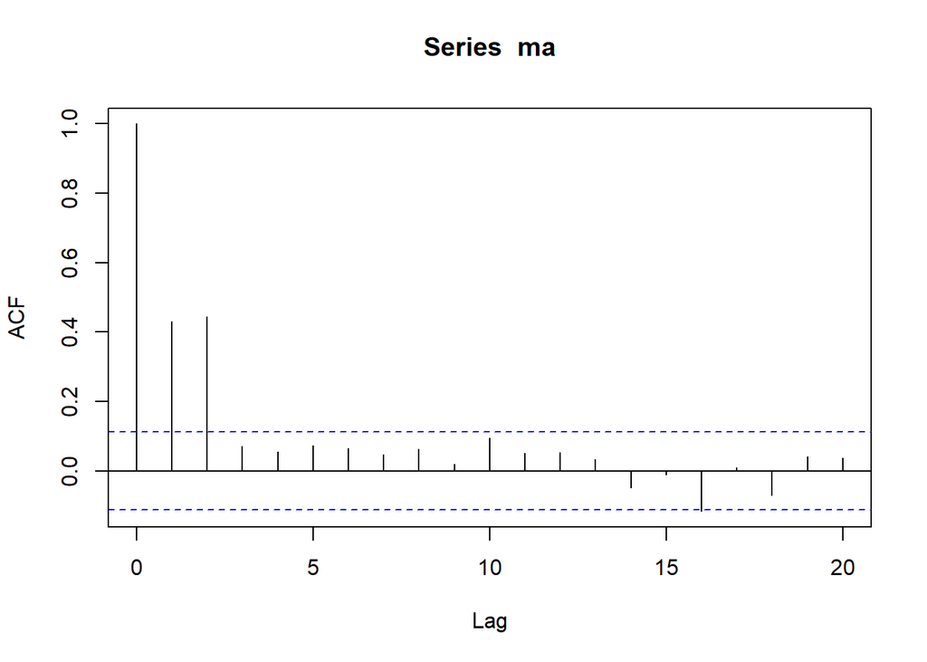

```r
acf(ma,lag.max = 20)
```

Berdasarkan plot AFC tersebut, terlihat bahwa plot ACF *cuts off* di lag kedua.

### Plot PACF

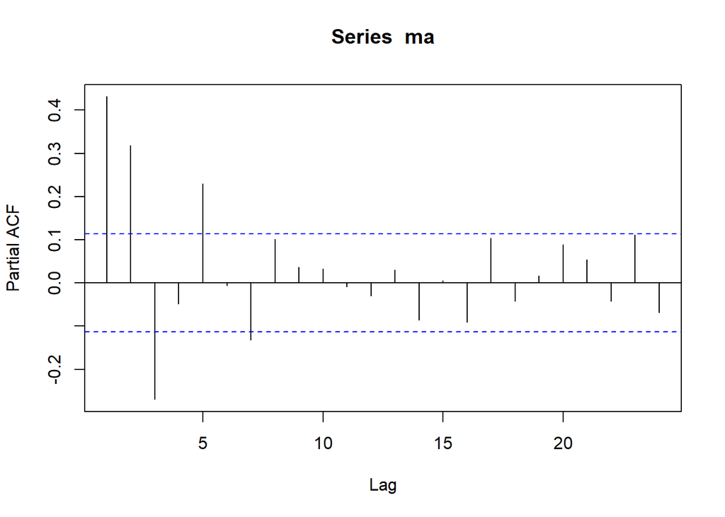

```r
pacf(ma)
```

Berdasarkan plot PACF tersebut, terlihat bahwa plot PACF cenderung *tails off* dan membentuk gelombang sinus

### Plot EACF

```r
TSA::eacf(ma)
```

```
## AR/MA
##   0 1 2 3 4 5 6 7 8 9 10 11 12 13
## 0 x x o o o o o o o o o  o  o  o
## 1 x x x o o o o o o o o  o  o  o
## 2 x x x x o o o o o o o  o  o  o
## 3 x x x o x o o o o o o  o  o  o
## 4 x x x x o o o o o o o  o  o  o
## 5 o x x x x o x o o o o  o  o  o
## 6 o x x x o o x o o o o  o  o  o
## 7 x x o x x x x o o o o  o  o  o
```

Berdasarkan pola segitiga nol pada plot EACF, terlihat bahwa segitiga nol berada pada ordo AR(0) dan ordo MA(2).

### Scatterplot Antar Lag

#### Korelasi antara $Y_t$ dengan $Y_{t-1}$

```r
#Yt
yt_ma <- ma[-1]
yt_ma
```

```
##   [1]  0.29135800  0.12331246  0.08496588 -0.84149976 -0.27398729  1.08579621
##   [7]  3.43851872  3.56919346  2.72533760  0.30540490  0.85829982  1.19602414
##  [13]  1.57447881  0.47141530 -1.21399136  0.25540415 -0.50793846  1.45617955
##  [19] -0.62102948  1.02630223 -0.14556241 -0.42166034 -0.73092074  0.04439800
##  [25]  1.46528904  0.25396704 -0.35636573  1.01791381 -1.14584421  1.97569955
##  [31]  0.72727272  0.30647402  0.64908617  0.20087022  0.81060701 -0.21195670
##  [37] -0.07582832  1.73444171  0.78196488  2.51136395  1.16592001  2.36072073
##  [43]  1.73202066  0.66556235  0.58048539  0.33317555  3.02579859  2.95974700
##  [49]  2.09135160  3.75294539  1.59823021  2.05741014  1.64778502  0.05428414
##  [55] -0.78813732 -1.22972997  0.53568418 -1.29146257  0.04063329  0.11865003
##  [61] -0.04108546  2.35937206 -0.04889490 -0.91521168 -3.00905097 -2.73907861
##  [67]  0.37411931 -1.16391294 -0.71541680  0.13549635 -0.25991885  1.70105138
##  [73] -0.67344480  0.69551754 -1.61287074  0.25617285 -0.14330040 -0.72995774
##  [79] -1.79078625 -3.27711289 -2.77911656 -2.11619386 -0.88191185 -0.35341678
##  [85] -0.45790314 -1.41227893  0.01844216 -1.61308478 -2.00097369 -1.29517607
```

[output cut: 35 more lines]

```r
#Yt-1
yt_1_ma <- ma[-300]
yt_1_ma
```

```
##   [1] -0.14504691  0.29135800  0.12331246  0.08496588 -0.84149976 -0.27398729
##   [7]  1.08579621  3.43851872  3.56919346  2.72533760  0.30540490  0.85829982
##  [13]  1.19602414  1.57447881  0.47141530 -1.21399136  0.25540415 -0.50793846
##  [19]  1.45617955 -0.62102948  1.02630223 -0.14556241 -0.42166034 -0.73092074
##  [25]  0.04439800  1.46528904  0.25396704 -0.35636573  1.01791381 -1.14584421
##  [31]  1.97569955  0.72727272  0.30647402  0.64908617  0.20087022  0.81060701
##  [37] -0.21195670 -0.07582832  1.73444171  0.78196488  2.51136395  1.16592001
##  [43]  2.36072073  1.73202066  0.66556235  0.58048539  0.33317555  3.02579859
##  [49]  2.95974700  2.09135160  3.75294539  1.59823021  2.05741014  1.64778502
##  [55]  0.05428414 -0.78813732 -1.22972997  0.53568418 -1.29146257  0.04063329
##  [61]  0.11865003 -0.04108546  2.35937206 -0.04889490 -0.91521168 -3.00905097
##  [67] -2.73907861  0.37411931 -1.16391294 -0.71541680  0.13549635 -0.25991885
##  [73]  1.70105138 -0.67344480  0.69551754 -1.61287074  0.25617285 -0.14330040
##  [79] -0.72995774 -1.79078625 -3.27711289 -2.77911656 -2.11619386 -0.88191185
##  [85] -0.35341678 -0.45790314 -1.41227893  0.01844216 -1.61308478 -2.00097369
```

[output cut: 35 more lines]

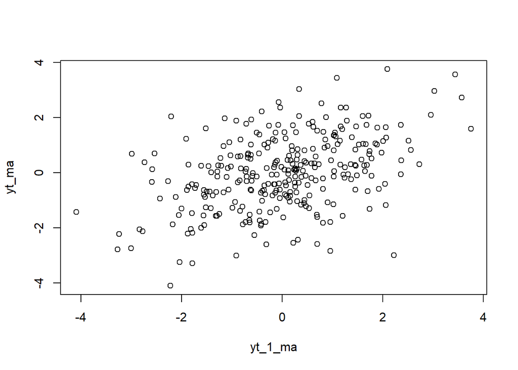

```r
plot(y=yt_ma,x=yt_1_ma)
```

Berdasarkan scatterplot tersebut, terlihat bahwa terdapat hubungan positif antara $Y_t$ dengan $Y_{t-1}$. Hal ini sesuai dengan teori yang ada.

```r
cor(yt_ma,yt_1_ma)
```

```
## [1] 0.4314634
```

Korelasi antara $Y_t$ dengan $Y_{t-1}$ dari hasil simulasi mendekati perhitungan teoritis yaitu

$$\rho_1=\frac{-\theta_1+\theta_1\theta_2}{1+\theta_1^2+\theta_2^2}=\frac{-(-0.4)+(-0.4)(-0.6)}{1+(-0.4)^2+(-0.6)^2}=0.42$$

#### Korelasi antara $Y_t$ dengan $Y_{t-2}$

```r
#Yt
yt_ma2 <- ma[-c(1,2)]
yt_ma2
```

```
##   [1]  0.12331246  0.08496588 -0.84149976 -0.27398729  1.08579621  3.43851872
##   [7]  3.56919346  2.72533760  0.30540490  0.85829982  1.19602414  1.57447881
##  [13]  0.47141530 -1.21399136  0.25540415 -0.50793846  1.45617955 -0.62102948
##  [19]  1.02630223 -0.14556241 -0.42166034 -0.73092074  0.04439800  1.46528904
##  [25]  0.25396704 -0.35636573  1.01791381 -1.14584421  1.97569955  0.72727272
##  [31]  0.30647402  0.64908617  0.20087022  0.81060701 -0.21195670 -0.07582832
##  [37]  1.73444171  0.78196488  2.51136395  1.16592001  2.36072073  1.73202066
##  [43]  0.66556235  0.58048539  0.33317555  3.02579859  2.95974700  2.09135160
##  [49]  3.75294539  1.59823021  2.05741014  1.64778502  0.05428414 -0.78813732
##  [55] -1.22972997  0.53568418 -1.29146257  0.04063329  0.11865003 -0.04108546
##  [61]  2.35937206 -0.04889490 -0.91521168 -3.00905097 -2.73907861  0.37411931
##  [67] -1.16391294 -0.71541680  0.13549635 -0.25991885  1.70105138 -0.67344480
##  [73]  0.69551754 -1.61287074  0.25617285 -0.14330040 -0.72995774 -1.79078625
##  [79] -3.27711289 -2.77911656 -2.11619386 -0.88191185 -0.35341678 -0.45790314
##  [85] -1.41227893  0.01844216 -1.61308478 -2.00097369 -1.29517607 -1.55938667
```

[output cut: 35 more lines]

```r
#Yt-2
yt_2_ma <- ma[-c(299,300)]
yt_2_ma
```

```
##   [1] -0.14504691  0.29135800  0.12331246  0.08496588 -0.84149976 -0.27398729
##   [7]  1.08579621  3.43851872  3.56919346  2.72533760  0.30540490  0.85829982
##  [13]  1.19602414  1.57447881  0.47141530 -1.21399136  0.25540415 -0.50793846
##  [19]  1.45617955 -0.62102948  1.02630223 -0.14556241 -0.42166034 -0.73092074
##  [25]  0.04439800  1.46528904  0.25396704 -0.35636573  1.01791381 -1.14584421
##  [31]  1.97569955  0.72727272  0.30647402  0.64908617  0.20087022  0.81060701
##  [37] -0.21195670 -0.07582832  1.73444171  0.78196488  2.51136395  1.16592001
##  [43]  2.36072073  1.73202066  0.66556235  0.58048539  0.33317555  3.02579859
##  [49]  2.95974700  2.09135160  3.75294539  1.59823021  2.05741014  1.64778502
##  [55]  0.05428414 -0.78813732 -1.22972997  0.53568418 -1.29146257  0.04063329
##  [61]  0.11865003 -0.04108546  2.35937206 -0.04889490 -0.91521168 -3.00905097
##  [67] -2.73907861  0.37411931 -1.16391294 -0.71541680  0.13549635 -0.25991885
##  [73]  1.70105138 -0.67344480  0.69551754 -1.61287074  0.25617285 -0.14330040
##  [79] -0.72995774 -1.79078625 -3.27711289 -2.77911656 -2.11619386 -0.88191185
##  [85] -0.35341678 -0.45790314 -1.41227893  0.01844216 -1.61308478 -2.00097369
```

[output cut: 35 more lines]

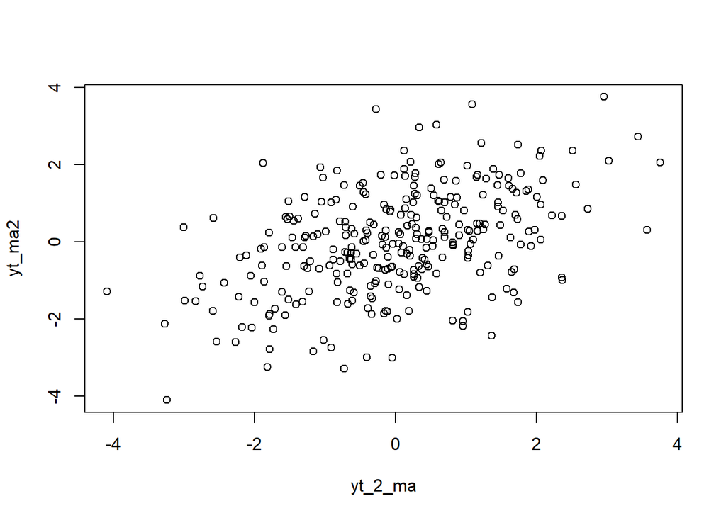

```r
plot(y=yt_ma2,x=yt_2_ma)
```

Berdasarkan scatterplot tersebut, terlihat bahwa terdapat hubungan positif antara $Y_t$ dengan $Y_{t-2}$. Hal ini sesuai dengan teori yang ada

```r
cor(yt_ma2,yt_2_ma)
```

```
## [1] 0.4461264
```

Korelasi antara $Y_t$ dengan $Y_{t-2}$ hasil simulasi mendekati teori yang ada yaitu

$$\rho_1=\frac{-\theta_2}{1+\theta_1^2+\theta_2^2}=\frac{-(-0.6)}{1+(-0.4)^2+(-0.6)^2}=0.39$$

#### Korelasi antara $Y_t$ dengan $Y_{t-3}$

```r
#Yt
yt_ma3 <- ma[-c(1,2,3)]
yt_ma3
```

```
##   [1]  0.08496588 -0.84149976 -0.27398729  1.08579621  3.43851872  3.56919346
##   [7]  2.72533760  0.30540490  0.85829982  1.19602414  1.57447881  0.47141530
##  [13] -1.21399136  0.25540415 -0.50793846  1.45617955 -0.62102948  1.02630223
##  [19] -0.14556241 -0.42166034 -0.73092074  0.04439800  1.46528904  0.25396704
##  [25] -0.35636573  1.01791381 -1.14584421  1.97569955  0.72727272  0.30647402
##  [31]  0.64908617  0.20087022  0.81060701 -0.21195670 -0.07582832  1.73444171
##  [37]  0.78196488  2.51136395  1.16592001  2.36072073  1.73202066  0.66556235
##  [43]  0.58048539  0.33317555  3.02579859  2.95974700  2.09135160  3.75294539
##  [49]  1.59823021  2.05741014  1.64778502  0.05428414 -0.78813732 -1.22972997
##  [55]  0.53568418 -1.29146257  0.04063329  0.11865003 -0.04108546  2.35937206
##  [61] -0.04889490 -0.91521168 -3.00905097 -2.73907861  0.37411931 -1.16391294
##  [67] -0.71541680  0.13549635 -0.25991885  1.70105138 -0.67344480  0.69551754
##  [73] -1.61287074  0.25617285 -0.14330040 -0.72995774 -1.79078625 -3.27711289
##  [79] -2.77911656 -2.11619386 -0.88191185 -0.35341678 -0.45790314 -1.41227893
##  [85]  0.01844216 -1.61308478 -2.00097369 -1.29517607 -1.55938667 -0.62405522
```

[output cut: 35 more lines]

```r
#Yt-3
yt_3_ma <- ma[-c(298,299,300)]
yt_3_ma
```

```
##   [1] -0.14504691  0.29135800  0.12331246  0.08496588 -0.84149976 -0.27398729
##   [7]  1.08579621  3.43851872  3.56919346  2.72533760  0.30540490  0.85829982
##  [13]  1.19602414  1.57447881  0.47141530 -1.21399136  0.25540415 -0.50793846
##  [19]  1.45617955 -0.62102948  1.02630223 -0.14556241 -0.42166034 -0.73092074
##  [25]  0.04439800  1.46528904  0.25396704 -0.35636573  1.01791381 -1.14584421
##  [31]  1.97569955  0.72727272  0.30647402  0.64908617  0.20087022  0.81060701
##  [37] -0.21195670 -0.07582832  1.73444171  0.78196488  2.51136395  1.16592001
##  [43]  2.36072073  1.73202066  0.66556235  0.58048539  0.33317555  3.02579859
##  [49]  2.95974700  2.09135160  3.75294539  1.59823021  2.05741014  1.64778502
##  [55]  0.05428414 -0.78813732 -1.22972997  0.53568418 -1.29146257  0.04063329
##  [61]  0.11865003 -0.04108546  2.35937206 -0.04889490 -0.91521168 -3.00905097
##  [67] -2.73907861  0.37411931 -1.16391294 -0.71541680  0.13549635 -0.25991885
##  [73]  1.70105138 -0.67344480  0.69551754 -1.61287074  0.25617285 -0.14330040
##  [79] -0.72995774 -1.79078625 -3.27711289 -2.77911656 -2.11619386 -0.88191185
##  [85] -0.35341678 -0.45790314 -1.41227893  0.01844216 -1.61308478 -2.00097369
```

[output cut: 35 more lines]

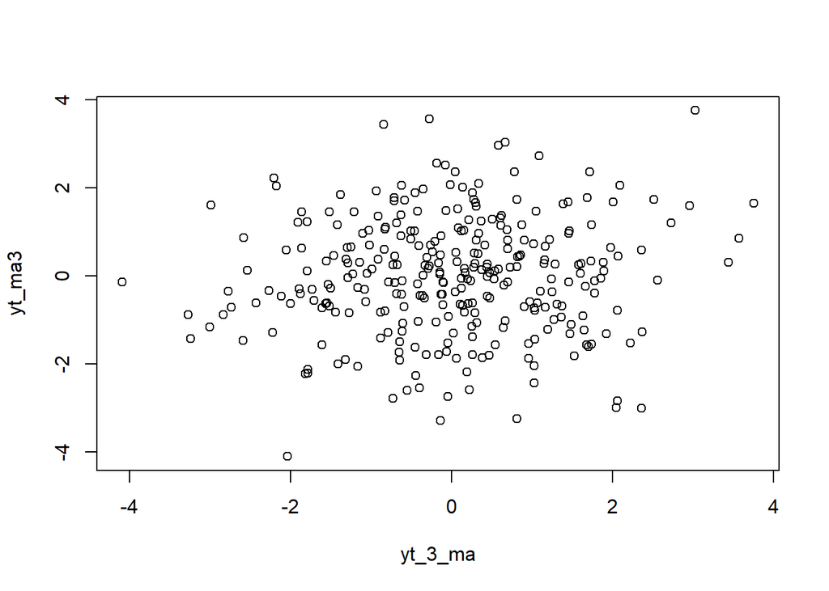

```r
plot(y=yt_ma3,x=yt_3_ma)
```

Berdasarkan scatterplot tersebut, terlihat bahwa cenderung tidak terdapat hubungan antara $Y_t$ dengan $Y_{t-3}$.

```r
cor(yt_ma3,yt_3_ma)
```

```
## [1] 0.07118783
```

Korelasi antara $Y_t$ dengan $Y_{t-3}$ hasil simulasi mendekati teori yang ada yaitu 0.

## Proses AR

Proses AR dapat dituliskan sebagai berikut:

$$y_{t} = c + e_t + \phi_{1}Y_{t-1} +
\phi_{2}Y_{t-2} + \dots + \phi_{q}Y_{t-q} = c+{e_t+\sum_{i=1}^p
\phi_iY_{t-i}}$$
Terlihat bahwa $Y_t$ berperan penting dalam pembangkitan proses AR.

## Pembangkitan Proses AR

AR(2) dengan $\phi_1 = 0.5$ dan $\phi_2=0.2$ sebanyak 300 observasi dan $c=0$.

```r
set.seed(073)
```

Nilai-nilai selanjutnya dapat dicari melalui *loop*. Bentuk loop dapat dilihat dari rumus AR(2) yang hendak dibangkitkan:

$$Y_t = e_t+0.5Y_{t-1}+0.2Y_{t-2}$$

```r
n<-length(wn)
n
```

```
## [1] 300
```

```r
ar <- c(1:n)
for (i in 3:n) {ar[i]<-wn[i]+0.5*ar[i-1]+0.2*ar[i-2]}
ar
```

```
##   [1]  1.000000000  2.000000000  1.293797405  0.919530814 -0.128306162
##   [6]  0.260918940  1.642226737  3.612144959  3.685715066  3.026836551
##  [11]  1.440627835  2.231024409  2.723484715  2.311281367  1.178511107
##  [16] -0.255749405  1.199232075  0.388322618  1.299401957 -0.143735543
##  [21]  1.043518730  0.527908024 -0.476264557 -0.504839944  0.414994215
##  [26]  1.490124878  0.070989758 -0.550174721  1.564745150 -0.673543653
##  [31]  1.394848537  1.530048491  0.112331991  0.803526881  1.007556764
##  [36]  0.976949283  0.003046926  0.208381308  2.246817990  1.083362165
##  [41]  2.249887093  2.053032884  2.797342383  2.586108878  1.414843705
##  [46]  1.514102038  1.520019470  3.722953806  3.773178509  2.483378335
##  [51]  4.843772306  3.466494065  2.831770274  3.376302115  1.724080719
##  [56]  0.201062324  0.068367354  1.562615382 -0.865581132 -0.308340828
##  [61]  0.862930104 -0.034531271  1.962293663  0.445153259 -1.172725357
##  [66] -2.473826322 -2.347282694  0.241939059 -1.751043545 -2.127735544
##  [71]  0.083194422 -0.462416157  0.619506152 -0.742725335  0.331608968
```

[output cut: 45 more lines]

Selain menggunakan cara di atas, pembangkitan proses AR dapat dilakukan dengan fungsi `arima.sim()` sebagai berikut.

```r
set.seed(078)
ar2 <- arima.sim(list(order=c(2,0,0), ar=c(0.5,0.2)), n=300) #c(p,d,q)
ar2
```

```
## Time Series:
## Start = 1
## End = 300
## Frequency = 1
##   [1] -0.822299326  0.700455518  0.328890070  0.111270751 -0.112318902
##   [6]  0.967271200 -0.682973894 -0.949898807  0.274494742  0.948890595
##  [11]  0.490953684 -0.001196333  0.825697246  1.407480049  0.756071120
##  [16] -0.472362309 -0.024042313 -0.049902934 -0.253818607 -0.667459850
##  [21] -1.081855725 -1.417129571 -0.153789865  0.058609705  2.051990012
##  [26]  0.791280581 -0.506293683  0.750054390  0.874018121  2.295137706
##  [31]  3.407366985 -0.964135528  0.138635654  0.836621400 -0.135064550
##  [36] -1.051114186  0.276107268  0.463449331  1.126074464 -1.344100135
##  [41] -1.198349094  0.458807714 -0.986777753 -1.223287211 -1.370436577
##  [46] -0.358599386 -0.540812068 -2.028674679 -0.545299636 -1.668084326
##  [51] -0.526165573 -0.960903026 -2.146443058 -1.320992719 -1.280928698
```

[output cut: 49 more lines]

### Plot Time Series

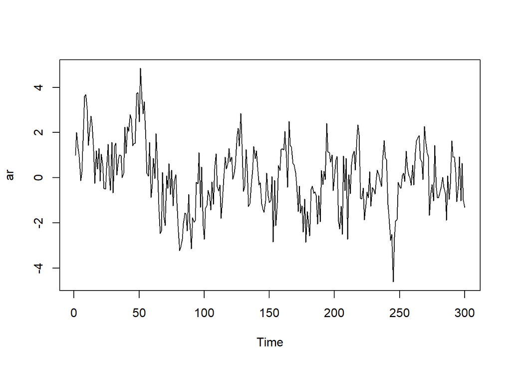

```r
ts.plot(ar)
```

Berdasarkan plot time series tersebut terlihat bahwa data cenderung stasioner pada rataan.

### Plot ACF

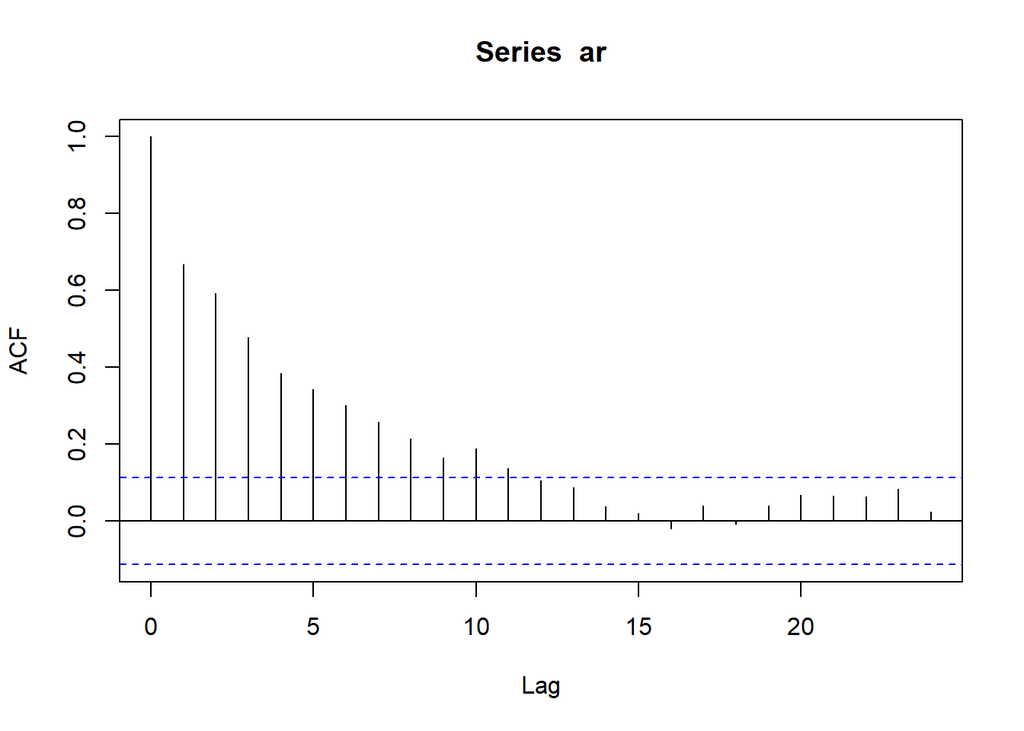

```r
acf(ar)
```

Berdasarkan plot ACF tersebut terlihat bahwa plot ACF cenderung *tails off* dan cenderung membentuk pola grafik sinus

### Plot PACF

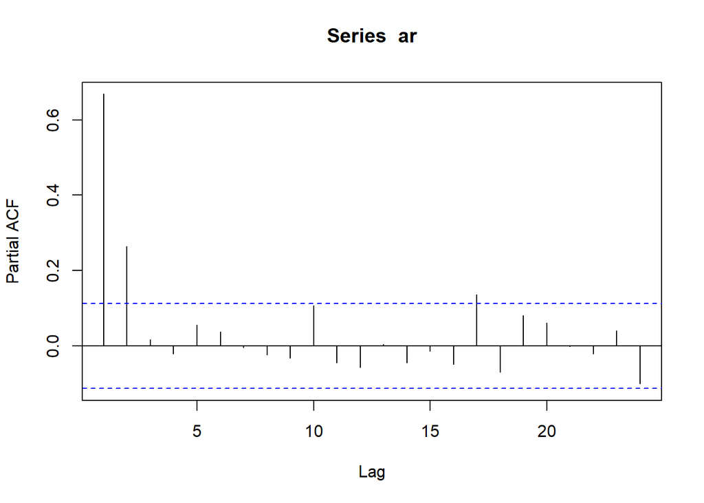

```r
pacf(ar)
```

Berdasarkan plot PACF tersebut, terlihat bahwa plot PACF *cuts off* pada lag kedua, sejalan dengan teori yang ada.

### Plot EACF

```r
TSA::eacf(ar)
```

```
## AR/MA
##   0 1 2 3 4 5 6 7 8 9 10 11 12 13
## 0 x x x x x x x x x x x  o  o  o
## 1 x o o o o o o o o x o  o  o  o
## 2 o o o o o o o o o x o  o  o  o
## 3 x o x o o o o o o o o  o  o  o
## 4 x o x x o o o o o o o  o  o  o
## 5 x x o o o o o o o o o  o  o  o
## 6 o x o o o o o o o o o  o  o  o
## 7 x x o o x o o o o o o  o  o  o
```

Berdasarkan pola segitiga nol pada plot EACF, terlihat bahwa segitiga nol berada pada ordo AR(1) dan ordo MA(1)

### Scatterplot Antar Lag

#### Korelasi antara $Y_t$ dengan $Y_{t-1}$

```r
#Yt
yt_ar <- ar[-1]
yt_ar
```

```
##   [1]  2.000000000  1.293797405  0.919530814 -0.128306162  0.260918940
##   [6]  1.642226737  3.612144959  3.685715066  3.026836551  1.440627835
##  [11]  2.231024409  2.723484715  2.311281367  1.178511107 -0.255749405
##  [16]  1.199232075  0.388322618  1.299401957 -0.143735543  1.043518730
##  [21]  0.527908024 -0.476264557 -0.504839944  0.414994215  1.490124878
##  [26]  0.070989758 -0.550174721  1.564745150 -0.673543653  1.394848537
##  [31]  1.530048491  0.112331991  0.803526881  1.007556764  0.976949283
##  [36]  0.003046926  0.208381308  2.246817990  1.083362165  2.249887093
##  [41]  2.053032884  2.797342383  2.586108878  1.414843705  1.514102038
##  [46]  1.520019470  3.722953806  3.773178509  2.483378335  4.843772306
##  [51]  3.466494065  2.831770274  3.376302115  1.724080719  0.201062324
##  [56]  0.068367354  1.562615382 -0.865581132 -0.308340828  0.862930104
##  [61] -0.034531271  1.962293663  0.445153259 -1.172725357 -2.473826322
##  [66] -2.347282694  0.241939059 -1.751043545 -2.127735544  0.083194422
##  [71] -0.462416157  0.619506152 -0.742725335  0.331608968 -1.251242381
```

[output cut: 45 more lines]

```r
#Yt-1
yt_1_ar <- ar[-300]
yt_1_ar
```

```
##   [1]  1.000000000  2.000000000  1.293797405  0.919530814 -0.128306162
##   [6]  0.260918940  1.642226737  3.612144959  3.685715066  3.026836551
##  [11]  1.440627835  2.231024409  2.723484715  2.311281367  1.178511107
##  [16] -0.255749405  1.199232075  0.388322618  1.299401957 -0.143735543
##  [21]  1.043518730  0.527908024 -0.476264557 -0.504839944  0.414994215
##  [26]  1.490124878  0.070989758 -0.550174721  1.564745150 -0.673543653
##  [31]  1.394848537  1.530048491  0.112331991  0.803526881  1.007556764
##  [36]  0.976949283  0.003046926  0.208381308  2.246817990  1.083362165
##  [41]  2.249887093  2.053032884  2.797342383  2.586108878  1.414843705
##  [46]  1.514102038  1.520019470  3.722953806  3.773178509  2.483378335
##  [51]  4.843772306  3.466494065  2.831770274  3.376302115  1.724080719
##  [56]  0.201062324  0.068367354  1.562615382 -0.865581132 -0.308340828
##  [61]  0.862930104 -0.034531271  1.962293663  0.445153259 -1.172725357
##  [66] -2.473826322 -2.347282694  0.241939059 -1.751043545 -2.127735544
##  [71]  0.083194422 -0.462416157  0.619506152 -0.742725335  0.331608968
```

[output cut: 45 more lines]

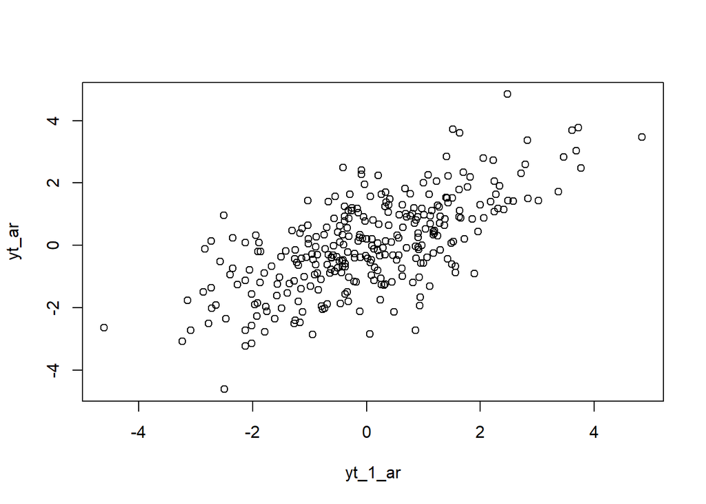

```r
plot(y=yt_ar,x=yt_1_ar)
```

Berdasarkan scatterplot tersebut, terlihat bahwa terdapat hubungan positif antara $Y_t$ dengan $Y_{t-1}$. Hal ini sesuai dengan teori yang ada

```r
cor(yt_ar,yt_1_ar)
```

```
## [1] 0.6701653
```

Korelasi antara $Y_t$ dengan $Y_{t-1}$ dari hasil simulasi mendekati perhitungan teoritis yaitu $\rho_1=\frac{\phi_1}{(1-\phi_2)}=\frac{0.5}{(1-0.2)}=0.63$

#### Korelasi antara $Y_t$ dengan $Y_{t-2}$

```r
#Yt
yt_ar2 <- ar[-c(1,2)]
yt_ar2
```

```
##   [1]  1.293797405  0.919530814 -0.128306162  0.260918940  1.642226737
##   [6]  3.612144959  3.685715066  3.026836551  1.440627835  2.231024409
##  [11]  2.723484715  2.311281367  1.178511107 -0.255749405  1.199232075
##  [16]  0.388322618  1.299401957 -0.143735543  1.043518730  0.527908024
##  [21] -0.476264557 -0.504839944  0.414994215  1.490124878  0.070989758
##  [26] -0.550174721  1.564745150 -0.673543653  1.394848537  1.530048491
##  [31]  0.112331991  0.803526881  1.007556764  0.976949283  0.003046926
##  [36]  0.208381308  2.246817990  1.083362165  2.249887093  2.053032884
##  [41]  2.797342383  2.586108878  1.414843705  1.514102038  1.520019470
##  [46]  3.722953806  3.773178509  2.483378335  4.843772306  3.466494065
##  [51]  2.831770274  3.376302115  1.724080719  0.201062324  0.068367354
##  [56]  1.562615382 -0.865581132 -0.308340828  0.862930104 -0.034531271
##  [61]  1.962293663  0.445153259 -1.172725357 -2.473826322 -2.347282694
##  [66]  0.241939059 -1.751043545 -2.127735544  0.083194422 -0.462416157
##  [71]  0.619506152 -0.742725335  0.331608968 -1.251242381 -0.143168072
```

[output cut: 45 more lines]

```r
#Yt-2
yt_2_ar <- ar[-c(299,300)]
yt_2_ar
```

```
##   [1]  1.000000000  2.000000000  1.293797405  0.919530814 -0.128306162
##   [6]  0.260918940  1.642226737  3.612144959  3.685715066  3.026836551
##  [11]  1.440627835  2.231024409  2.723484715  2.311281367  1.178511107
##  [16] -0.255749405  1.199232075  0.388322618  1.299401957 -0.143735543
##  [21]  1.043518730  0.527908024 -0.476264557 -0.504839944  0.414994215
##  [26]  1.490124878  0.070989758 -0.550174721  1.564745150 -0.673543653
##  [31]  1.394848537  1.530048491  0.112331991  0.803526881  1.007556764
##  [36]  0.976949283  0.003046926  0.208381308  2.246817990  1.083362165
##  [41]  2.249887093  2.053032884  2.797342383  2.586108878  1.414843705
##  [46]  1.514102038  1.520019470  3.722953806  3.773178509  2.483378335
##  [51]  4.843772306  3.466494065  2.831770274  3.376302115  1.724080719
##  [56]  0.201062324  0.068367354  1.562615382 -0.865581132 -0.308340828
##  [61]  0.862930104 -0.034531271  1.962293663  0.445153259 -1.172725357
##  [66] -2.473826322 -2.347282694  0.241939059 -1.751043545 -2.127735544
##  [71]  0.083194422 -0.462416157  0.619506152 -0.742725335  0.331608968
```

[output cut: 45 more lines]

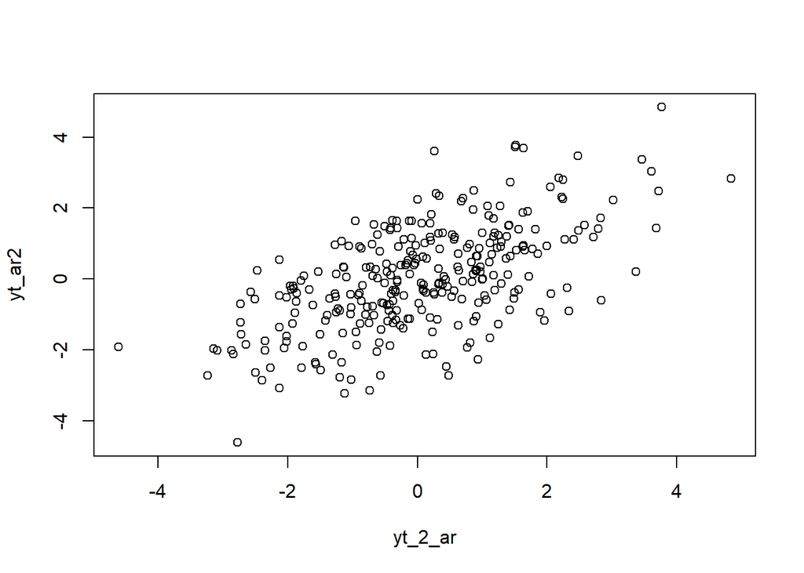

```r
plot(y=yt_ar2,x=yt_2_ar)
```

Berdasarkan scatterplot tersebut, terlihat bahwa terdapat hubungan positif antara $Y_t$ dengan $Y_{t-2}$. Hal ini sesuai dengan teori yang ada

```r
cor(yt_ar2,yt_2_ar)
```

```
## [1] 0.596921
```

Korelasi antara $Y_t$ dengan $Y_{t-2}$ dari hasil simulasi mendekati perhitungan teoritis yaitu $\rho_2=\frac{\phi_2(1-\phi_2)+\phi_1^2}{(1-\phi_2)}=\frac{0.2(1-0.2)+0,5^2}{(1-0.2)}=0.51$

#### Korelasi antara $Y_t$ dengan $Y_{t-3}$

```r
#Yt
yt_ar3 <- ar[-c(1,2,3)]
yt_ar2
```

```
##   [1]  1.293797405  0.919530814 -0.128306162  0.260918940  1.642226737
##   [6]  3.612144959  3.685715066  3.026836551  1.440627835  2.231024409
##  [11]  2.723484715  2.311281367  1.178511107 -0.255749405  1.199232075
##  [16]  0.388322618  1.299401957 -0.143735543  1.043518730  0.527908024
##  [21] -0.476264557 -0.504839944  0.414994215  1.490124878  0.070989758
##  [26] -0.550174721  1.564745150 -0.673543653  1.394848537  1.530048491
##  [31]  0.112331991  0.803526881  1.007556764  0.976949283  0.003046926
##  [36]  0.208381308  2.246817990  1.083362165  2.249887093  2.053032884
##  [41]  2.797342383  2.586108878  1.414843705  1.514102038  1.520019470
##  [46]  3.722953806  3.773178509  2.483378335  4.843772306  3.466494065
##  [51]  2.831770274  3.376302115  1.724080719  0.201062324  0.068367354
##  [56]  1.562615382 -0.865581132 -0.308340828  0.862930104 -0.034531271
##  [61]  1.962293663  0.445153259 -1.172725357 -2.473826322 -2.347282694
##  [66]  0.241939059 -1.751043545 -2.127735544  0.083194422 -0.462416157
##  [71]  0.619506152 -0.742725335  0.331608968 -1.251242381 -0.143168072
```

[output cut: 45 more lines]

```r
#Yt-3
yt_3_ar <- ar[-c(298,299,300)]
yt_3_ar
```

```
##   [1]  1.000000000  2.000000000  1.293797405  0.919530814 -0.128306162
##   [6]  0.260918940  1.642226737  3.612144959  3.685715066  3.026836551
##  [11]  1.440627835  2.231024409  2.723484715  2.311281367  1.178511107
##  [16] -0.255749405  1.199232075  0.388322618  1.299401957 -0.143735543
##  [21]  1.043518730  0.527908024 -0.476264557 -0.504839944  0.414994215
##  [26]  1.490124878  0.070989758 -0.550174721  1.564745150 -0.673543653
##  [31]  1.394848537  1.530048491  0.112331991  0.803526881  1.007556764
##  [36]  0.976949283  0.003046926  0.208381308  2.246817990  1.083362165
##  [41]  2.249887093  2.053032884  2.797342383  2.586108878  1.414843705
##  [46]  1.514102038  1.520019470  3.722953806  3.773178509  2.483378335
##  [51]  4.843772306  3.466494065  2.831770274  3.376302115  1.724080719
##  [56]  0.201062324  0.068367354  1.562615382 -0.865581132 -0.308340828
##  [61]  0.862930104 -0.034531271  1.962293663  0.445153259 -1.172725357
##  [66] -2.473826322 -2.347282694  0.241939059 -1.751043545 -2.127735544
##  [71]  0.083194422 -0.462416157  0.619506152 -0.742725335  0.331608968
```

[output cut: 45 more lines]

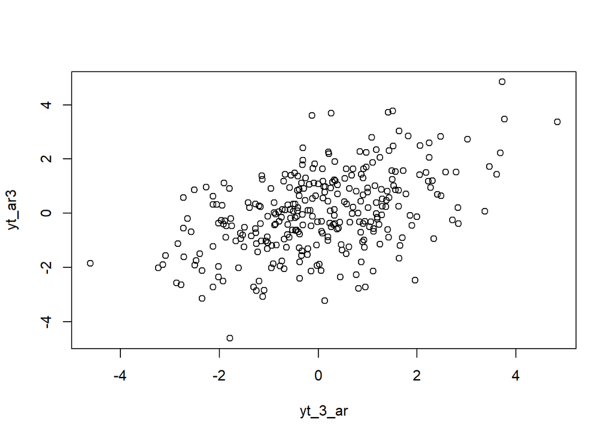

```r
plot(y=yt_ar3,x=yt_3_ar)
```

Berdasarkan scatterplot tersebut, terlihat bahwa terdapat hubungan positif antara $Y_t$ dengan $Y_{t-3}$. Hal ini sesuai dengan teori yang ada

```r
cor(yt_ar3,yt_3_ar)
```

```
## [1] 0.4805957
```

Korelasi antara $Y_t$ dengan $Y_{t-3}$ dari hasil simulasi mendekati perhitungan teoritis yaitu $\rho_3=\frac{\phi_1\phi_2+\phi_1^3}{(1-\phi_2)}+\phi_1\phi_2=\frac{0.5(0.2)+(0.5)^3}{(1-0.2)}+0.5(0.2)=0.38$

## Fungsi pembangkitan ARMA

Bentuk umum data berpola ARMA.

$$y_{t} = c + \sum_{i=1}^p \phi_{i}y_{t-i} + \sum_{j=1}^q e_{t-j}+ e_{t}$$

```r
set.seed(073)
n = length(wn)
phi1 = 0.5
phi2 = 0.2
theta1 = 0.4
theta2 = 0.6

y.arma=c(1:n)
for (i in 3:n){y.arma[i] = phi1*y.arma[i-1] + phi2*y.arma[i-2] + theta1*wn[i-1] + theta2*wn[i-2] + wn[i]}
```

Pembangkitan ARMA(p,q) juga dapat dilakukan dengan fungsi `arima.sim` sebagai berikut.

```r
arma22 <- arima.sim(list(order=c(2,0,2), ar = c(0.5,0.2), ma = c(0.4,0.6)), n=300)
arma22
```

```
## Time Series:
## Start = 1
## End = 300
## Frequency = 1
##   [1]  0.36880008  1.38460393 -0.37978223  2.06272923  1.68268089  1.56036031
##   [7]  1.76580251  1.39584354  1.86168928  0.99805664  0.79553785  2.33182196
##  [13]  2.10698343  4.03122005  3.60292673  4.96842811  4.93682006  4.12765800
##  [19]  3.63167840  2.97454635  5.23940745  6.17436000  6.22641309  8.10102394
##  [25]  6.89402480  7.12462733  6.58890365  4.77366143  2.91647413  1.18323938
##  [31]  1.71059870 -0.19951534  0.28299536  0.22024464  0.12563593  2.46623895
##  [37]  1.20935176  0.18271199 -2.67582463 -4.04044853 -2.18126988 -3.06263759
##  [43] -2.68298957 -1.81852595 -1.70577974  0.48445632 -0.77237258  0.40622251
##  [49] -1.56423400 -0.44469965 -0.67849702 -1.15814619 -2.50555874 -4.76152150
##  [55] -5.66098905 -5.89899269 -4.96360601 -4.01501833 -3.45813350 -3.94434935
##  [61] -2.64535922 -3.72463426 -4.39236267 -4.23628425 -4.55600133 -3.74931274
```

[output cut: 39 more lines]

## Karakteristik ARMA(2,2)

### Plot Time Series

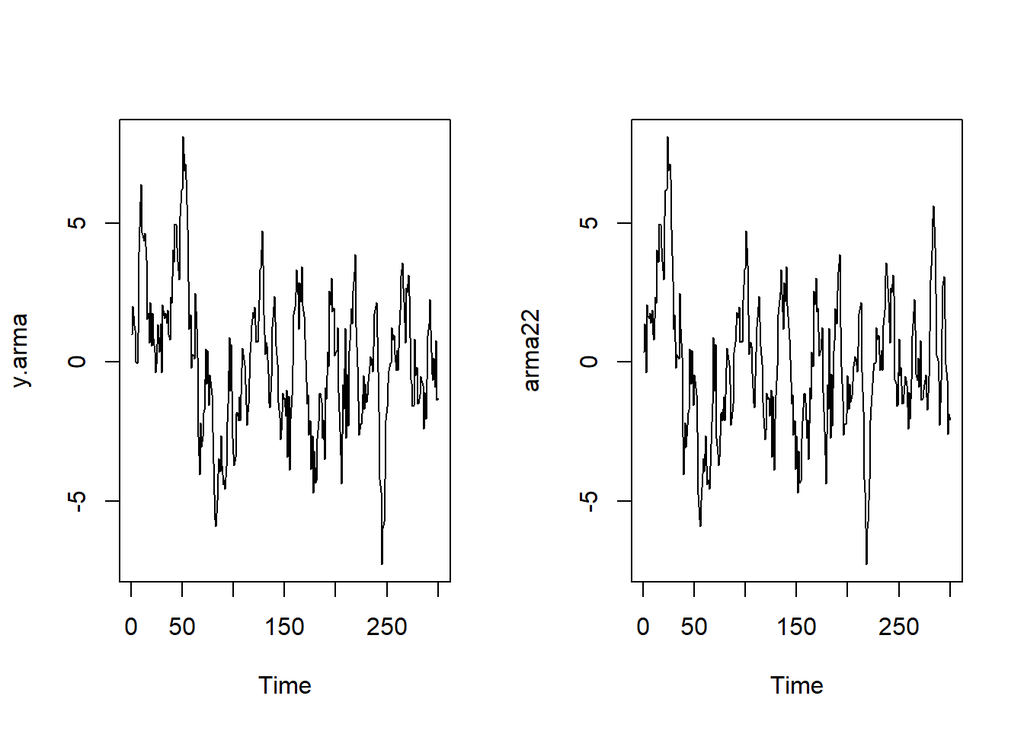

```r
par(mfrow = c(1, 2))
ts.plot(y.arma)
ts.plot(arma22)
```

```r
par(mfrow = c(1, 1))
```

Berdasarkan plot time series tersebut, terlihat bahwa model ARMA(2,2) cenderung stasioner dalam rataan.

### Plot ACF

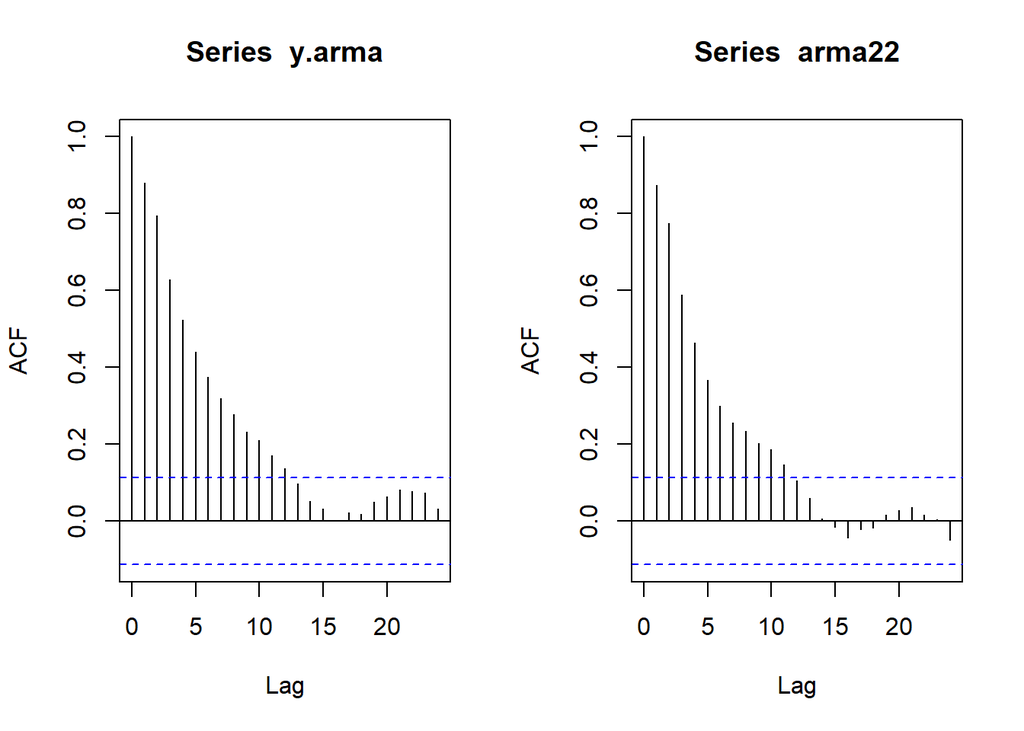

```r
par(mfrow = c(1, 2))
acf(y.arma)
acf(arma22)
```

```r
par(mfrow = c(1, 1))
```

Berdasarkan plot ACF tersebut, terlihat bahwa model ARMA(2,2) hasil simulasi memiliki plot ACF yang *tails off*, sesuai dengan teori yang ada.

### Plot PACF

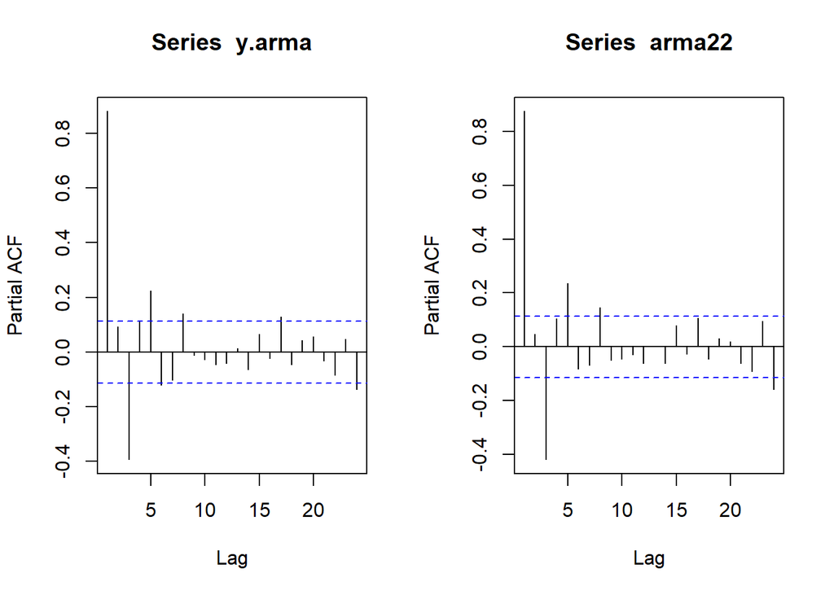

```r
par(mfrow = c(1, 2))
pacf(y.arma)
pacf(arma22)
```

```r
par(mfrow = c(1, 1))
```

Berdasarkan plot PACF tersebut, terlihat bahwa model ARMA(2,2) hasil simulasi memiliki plot PACF yang *tails off*, sesuai dengan teori.

### Plot EACF

```r
TSA::eacf(y.arma)
```

```
## AR/MA
##   0 1 2 3 4 5 6 7 8 9 10 11 12 13
## 0 x x x x x x x x x x x  x  o  o
## 1 o x x o o o o o o o o  o  o  o
## 2 x x x o o o o o o o o  o  o  o
## 3 x x x o o o o o o o o  o  o  o
## 4 x x x o o o o o o o o  o  o  o
## 5 x x x x o o o o o o o  o  o  o
## 6 x x o x o o o o o o o  o  o  o
## 7 x x o x o o o o o o o  o  o  o
```

```r
TSA::eacf(arma22)
```

```
## AR/MA
##   0 1 2 3 4 5 6 7 8 9 10 11 12 13
## 0 x x x x x x x x x x x  o  o  o
## 1 o x o o o o o o o o o  o  o  o
## 2 o x x o o o o o o o o  o  o  o
## 3 x x x o o o o o o o o  o  o  o
## 4 x x x x o o o o o o o  o  o  o
## 5 x x x o o x o o o o o  o  o  o
## 6 x x x x x x o o o o o  o  o  o
## 7 x x x o x x x o o o o  o  o  o
```

Berdasarkan pola segitiga nol pada plot EACF, terlihat bahwa segitiga nol berada pada ordo AR(1) dan ordo MA(3)

### Scatterplot Antar Lag

#### Korelasi antara $Y_t$ dengan $Y_{t-1}$

```r
#Yt
yt_arma <- arma22[-1]
yt_arma
```

```
##   [1]  1.38460393 -0.37978223  2.06272923  1.68268089  1.56036031  1.76580251
##   [7]  1.39584354  1.86168928  0.99805664  0.79553785  2.33182196  2.10698343
##  [13]  4.03122005  3.60292673  4.96842811  4.93682006  4.12765800  3.63167840
##  [19]  2.97454635  5.23940745  6.17436000  6.22641309  8.10102394  6.89402480
##  [25]  7.12462733  6.58890365  4.77366143  2.91647413  1.18323938  1.71059870
##  [31] -0.19951534  0.28299536  0.22024464  0.12563593  2.46623895  1.20935176
##  [37]  0.18271199 -2.67582463 -4.04044853 -2.18126988 -3.06263759 -2.68298957
##  [43] -1.81852595 -1.70577974  0.48445632 -0.77237258  0.40622251 -1.56423400
##  [49] -0.44469965 -0.67849702 -1.15814619 -2.50555874 -4.76152150 -5.66098905
##  [55] -5.89899269 -4.96360601 -4.01501833 -3.45813350 -3.94434935 -2.64535922
##  [61] -3.72463426 -4.39236267 -4.23628425 -4.55600133 -3.74931274 -2.14280177
##  [67] -1.48739652  0.88859088 -1.02138494  0.62629931 -2.72578576 -3.29403978
##  [73] -3.72603609 -3.40540311 -1.86355367 -1.80807073 -2.09777152 -1.26006541
##  [79] -2.09820978 -0.19672319  0.51368084  0.27694992 -0.10069337 -0.78188466
##  [85] -2.27657567 -1.80012556 -1.48799645  0.35052408  0.71976166  1.33602089
```

[output cut: 35 more lines]

```r
#Yt-1
yt_1_arma <- arma22[-300]
yt_1_arma
```

```
##   [1]  0.36880008  1.38460393 -0.37978223  2.06272923  1.68268089  1.56036031
##   [7]  1.76580251  1.39584354  1.86168928  0.99805664  0.79553785  2.33182196
##  [13]  2.10698343  4.03122005  3.60292673  4.96842811  4.93682006  4.12765800
##  [19]  3.63167840  2.97454635  5.23940745  6.17436000  6.22641309  8.10102394
##  [25]  6.89402480  7.12462733  6.58890365  4.77366143  2.91647413  1.18323938
##  [31]  1.71059870 -0.19951534  0.28299536  0.22024464  0.12563593  2.46623895
##  [37]  1.20935176  0.18271199 -2.67582463 -4.04044853 -2.18126988 -3.06263759
##  [43] -2.68298957 -1.81852595 -1.70577974  0.48445632 -0.77237258  0.40622251
##  [49] -1.56423400 -0.44469965 -0.67849702 -1.15814619 -2.50555874 -4.76152150
##  [55] -5.66098905 -5.89899269 -4.96360601 -4.01501833 -3.45813350 -3.94434935
##  [61] -2.64535922 -3.72463426 -4.39236267 -4.23628425 -4.55600133 -3.74931274
##  [67] -2.14280177 -1.48739652  0.88859088 -1.02138494  0.62629931 -2.72578576
##  [73] -3.29403978 -3.72603609 -3.40540311 -1.86355367 -1.80807073 -2.09777152
##  [79] -1.26006541 -2.09820978 -0.19672319  0.51368084  0.27694992 -0.10069337
##  [85] -0.78188466 -2.27657567 -1.80012556 -1.48799645  0.35052408  0.71976166
```

[output cut: 35 more lines]

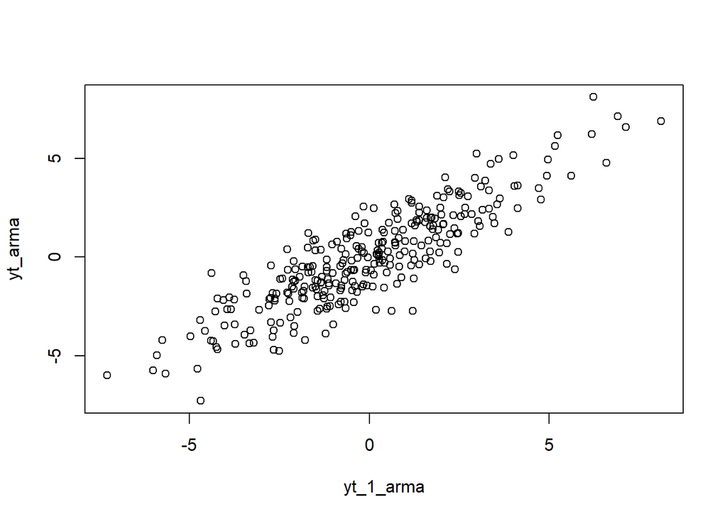

```r
plot(y=yt_arma,x=yt_1_arma)
```

Berdasarkan scatterplot tersebut, terlihat bahwa terdapat hubungan positif antara $Y_t$ dengan $Y_{t-1}$. Hal ini sesuai dengan teori yang ada

```r
cor(yt_arma,yt_1_arma)
```

```
## [1] 0.8749669
```

#### Korelasi antara $Y_t$ dengan $Y_{t-2}$

```r
#Yt
yt_arma <- arma22[-c(1,2)]
yt_arma
```

```
##   [1] -0.37978223  2.06272923  1.68268089  1.56036031  1.76580251  1.39584354
##   [7]  1.86168928  0.99805664  0.79553785  2.33182196  2.10698343  4.03122005
##  [13]  3.60292673  4.96842811  4.93682006  4.12765800  3.63167840  2.97454635
##  [19]  5.23940745  6.17436000  6.22641309  8.10102394  6.89402480  7.12462733
##  [25]  6.58890365  4.77366143  2.91647413  1.18323938  1.71059870 -0.19951534
##  [31]  0.28299536  0.22024464  0.12563593  2.46623895  1.20935176  0.18271199
##  [37] -2.67582463 -4.04044853 -2.18126988 -3.06263759 -2.68298957 -1.81852595
##  [43] -1.70577974  0.48445632 -0.77237258  0.40622251 -1.56423400 -0.44469965
##  [49] -0.67849702 -1.15814619 -2.50555874 -4.76152150 -5.66098905 -5.89899269
##  [55] -4.96360601 -4.01501833 -3.45813350 -3.94434935 -2.64535922 -3.72463426
##  [61] -4.39236267 -4.23628425 -4.55600133 -3.74931274 -2.14280177 -1.48739652
##  [67]  0.88859088 -1.02138494  0.62629931 -2.72578576 -3.29403978 -3.72603609
##  [73] -3.40540311 -1.86355367 -1.80807073 -2.09777152 -1.26006541 -2.09820978
##  [79] -0.19672319  0.51368084  0.27694992 -0.10069337 -0.78188466 -2.27657567
##  [85] -1.80012556 -1.48799645  0.35052408  0.71976166  1.33602089  1.78081273
```

[output cut: 35 more lines]

```r
#Yt-2
yt_2_arma <- arma22[-c(299,300)]
yt_2_arma
```

```
##   [1]  0.36880008  1.38460393 -0.37978223  2.06272923  1.68268089  1.56036031
##   [7]  1.76580251  1.39584354  1.86168928  0.99805664  0.79553785  2.33182196
##  [13]  2.10698343  4.03122005  3.60292673  4.96842811  4.93682006  4.12765800
##  [19]  3.63167840  2.97454635  5.23940745  6.17436000  6.22641309  8.10102394
##  [25]  6.89402480  7.12462733  6.58890365  4.77366143  2.91647413  1.18323938
##  [31]  1.71059870 -0.19951534  0.28299536  0.22024464  0.12563593  2.46623895
##  [37]  1.20935176  0.18271199 -2.67582463 -4.04044853 -2.18126988 -3.06263759
##  [43] -2.68298957 -1.81852595 -1.70577974  0.48445632 -0.77237258  0.40622251
##  [49] -1.56423400 -0.44469965 -0.67849702 -1.15814619 -2.50555874 -4.76152150
##  [55] -5.66098905 -5.89899269 -4.96360601 -4.01501833 -3.45813350 -3.94434935
##  [61] -2.64535922 -3.72463426 -4.39236267 -4.23628425 -4.55600133 -3.74931274
##  [67] -2.14280177 -1.48739652  0.88859088 -1.02138494  0.62629931 -2.72578576
##  [73] -3.29403978 -3.72603609 -3.40540311 -1.86355367 -1.80807073 -2.09777152
##  [79] -1.26006541 -2.09820978 -0.19672319  0.51368084  0.27694992 -0.10069337
##  [85] -0.78188466 -2.27657567 -1.80012556 -1.48799645  0.35052408  0.71976166
```

[output cut: 35 more lines]

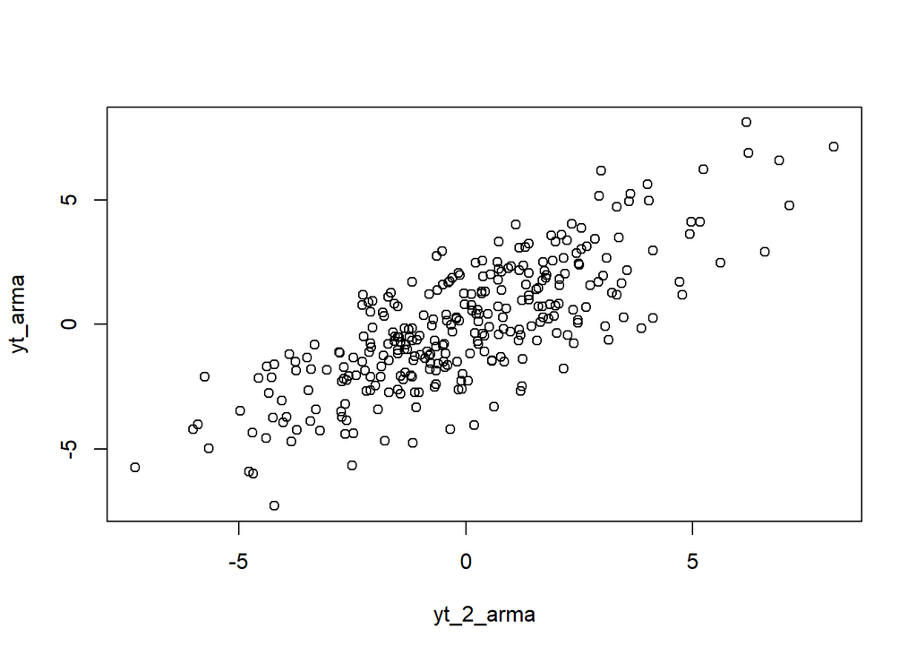

```r
plot(y=yt_arma,x=yt_2_arma)
```

Berdasarkan scatterplot tersebut, terlihat bahwa terdapat hubungan positif antara $Y_t$ dengan $Y_{t-2}$. Hal ini sesuai dengan teori yang ada

```r
cor(yt_arma,yt_2_arma)
```

```
## [1] 0.7770713
```

#### Korelasi antara $Y_t$ dengan $Y_{t-3}$

```r
#Yt
yt_arma <- arma22[-c(1,2,3)]
yt_arma
```

```
##   [1]  2.06272923  1.68268089  1.56036031  1.76580251  1.39584354  1.86168928
##   [7]  0.99805664  0.79553785  2.33182196  2.10698343  4.03122005  3.60292673
##  [13]  4.96842811  4.93682006  4.12765800  3.63167840  2.97454635  5.23940745
##  [19]  6.17436000  6.22641309  8.10102394  6.89402480  7.12462733  6.58890365
##  [25]  4.77366143  2.91647413  1.18323938  1.71059870 -0.19951534  0.28299536
##  [31]  0.22024464  0.12563593  2.46623895  1.20935176  0.18271199 -2.67582463
##  [37] -4.04044853 -2.18126988 -3.06263759 -2.68298957 -1.81852595 -1.70577974
##  [43]  0.48445632 -0.77237258  0.40622251 -1.56423400 -0.44469965 -0.67849702
##  [49] -1.15814619 -2.50555874 -4.76152150 -5.66098905 -5.89899269 -4.96360601
##  [55] -4.01501833 -3.45813350 -3.94434935 -2.64535922 -3.72463426 -4.39236267
##  [61] -4.23628425 -4.55600133 -3.74931274 -2.14280177 -1.48739652  0.88859088
##  [67] -1.02138494  0.62629931 -2.72578576 -3.29403978 -3.72603609 -3.40540311
##  [73] -1.86355367 -1.80807073 -2.09777152 -1.26006541 -2.09820978 -0.19672319
##  [79]  0.51368084  0.27694992 -0.10069337 -0.78188466 -2.27657567 -1.80012556
##  [85] -1.48799645  0.35052408  0.71976166  1.33602089  1.78081273  1.60397734
```

[output cut: 35 more lines]

```r
#Yt-3
yt_3_arma <- arma22[-c(298,299,300)]
yt_3_arma
```

```
##   [1]  0.36880008  1.38460393 -0.37978223  2.06272923  1.68268089  1.56036031
##   [7]  1.76580251  1.39584354  1.86168928  0.99805664  0.79553785  2.33182196
##  [13]  2.10698343  4.03122005  3.60292673  4.96842811  4.93682006  4.12765800
##  [19]  3.63167840  2.97454635  5.23940745  6.17436000  6.22641309  8.10102394
##  [25]  6.89402480  7.12462733  6.58890365  4.77366143  2.91647413  1.18323938
##  [31]  1.71059870 -0.19951534  0.28299536  0.22024464  0.12563593  2.46623895
##  [37]  1.20935176  0.18271199 -2.67582463 -4.04044853 -2.18126988 -3.06263759
##  [43] -2.68298957 -1.81852595 -1.70577974  0.48445632 -0.77237258  0.40622251
##  [49] -1.56423400 -0.44469965 -0.67849702 -1.15814619 -2.50555874 -4.76152150
##  [55] -5.66098905 -5.89899269 -4.96360601 -4.01501833 -3.45813350 -3.94434935
##  [61] -2.64535922 -3.72463426 -4.39236267 -4.23628425 -4.55600133 -3.74931274
##  [67] -2.14280177 -1.48739652  0.88859088 -1.02138494  0.62629931 -2.72578576
##  [73] -3.29403978 -3.72603609 -3.40540311 -1.86355367 -1.80807073 -2.09777152
##  [79] -1.26006541 -2.09820978 -0.19672319  0.51368084  0.27694992 -0.10069337
##  [85] -0.78188466 -2.27657567 -1.80012556 -1.48799645  0.35052408  0.71976166
```

[output cut: 35 more lines]

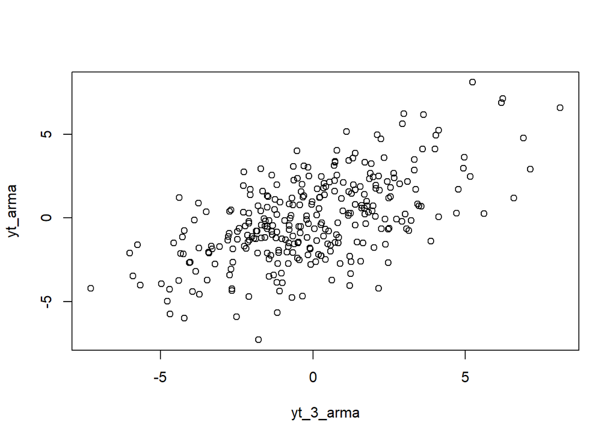

```r
plot(y=yt_arma,x=yt_3_arma)
```

Berdasarkan scatterplot tersebut, terlihat bahwa terdapat hubungan positif antara $Y_t$ dengan $Y_{t-3}$. Hal ini sesuai dengan teori yang ada.

```r
cor(yt_arma,yt_3_arma)
```

```
## [1] 0.5908247
```